# Deputados alinhados ao meio ambiente

Analisamos votações de Meio Ambiente ocorridas no plenário da Câmara em 2019. Calculamos a aderência dos deputados ao Governo nessas votações. A aderência vai de 0 a 100% sendo 100% o valor mais aderente ao Governo.

Calculamos a aderência para 467 deputados e mostramos a distribuição dessa variável seguir.

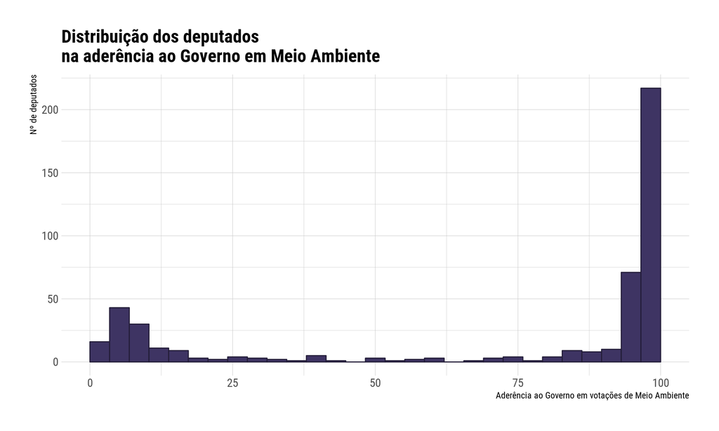

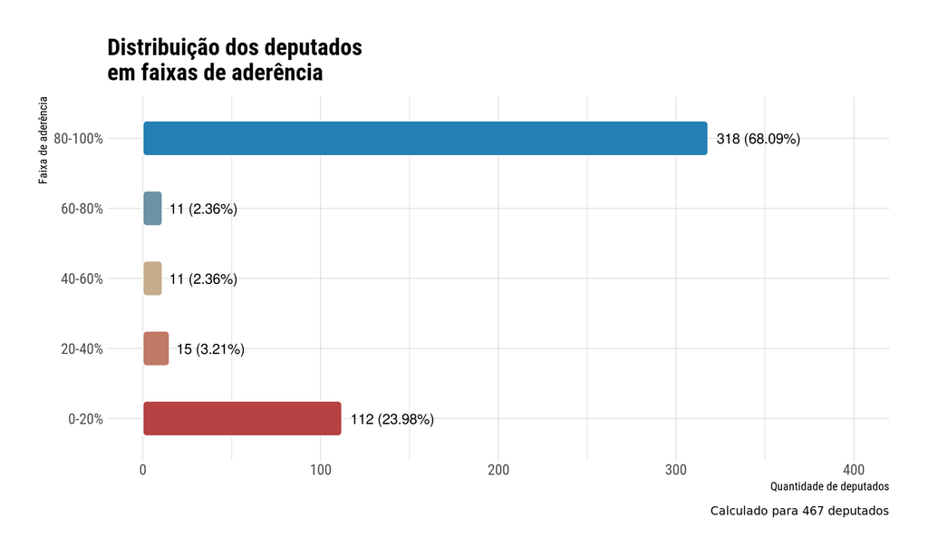

### Lista com aderência dos Deputados

| Nome | Partido | UF | Faltou | Seguiu | Não seguiu | Aderência (%) | Investimento do partido (%) |
| --- | --- | --- | --- | --- | --- | --- | --- |
| Frei Anastacio Ribeiro | PT | PB | 8 | 0 | 17 | 0 | 0.37 |
| Eduardo Bismarck | PDT | CE | 9 | 0 | 16 | 0 | 0 |
| Edmilson Rodrigues | PSOL | PA | 10 | 0 | 15 | 0 | 4.73 |
| Júlio Delgado | PSB | MG | 9 | 0 | 15 | 0 | 2.38 |
| Wolney Queiroz | PDT | PE | 10 | 0 | 15 | 0 | 3.69 |
| Jorge Solla | PT | BA | 11 | 0 | 14 | 0 | 0.84 |
| Vicentinho | PT | SP | 15 | 0 | 11 | 0 | 1.27 |
| Tabata Amaral | PDT | SP | 13 | 0 | 11 | 0 | 0.74 |
| Chico D'angelo | PDT | RJ | 15 | 0 | 10 | 0 | 4.75 |
| Tadeu Alencar | PSB | PE | 16 | 0 | 10 | 0 | 2.06 |

[output cut: 457 more lines]

### Lista de Deputados com aderência indefinida

| Nome | Partido | UF | Faltou | Seguiu | Não seguiu | Investimento do partido (%) |
| --- | --- | --- | --- | --- | --- | --- |
| Aguinaldo Ribeiro | PP | PB | 23 | 2 | 0 | 0.89 |
| Alex Manente | CIDADANIA | SP | 23 | 1 | 0 | 7.5 |
| Alexandre Serfiotis | PSD | RJ | 26 | 0 | 0 | 2.86 |
| Assis Carvalho | PT | PI | 26 | 0 | 0 | 0.72 |
| Benedita Da Silva | PT | RJ | 23 | 1 | 0 | 1.82 |
| Bruna Furlan | PSDB | SP | 25 | 0 | 0 | 2.96 |
| Claudio Cajado | PP | BA | 24 | 1 | 0 | 1.68 |
| Dagoberto Nogueira | PDT | MS | 26 | 0 | 0 | 3.54 |
| Edio Lopes | PL | RR | 23 | 1 | 0 | 1.84 |
| Eduardo Barbosa | PSDB | MG | 24 | 0 | 0 | 0.67 |

[output cut: 33 more lines]

### Relação entre atividade parlamentar e Aderência

No eixo x temos a aderência ao Governo em votações de Meio Ambiente. Já no eixo y temos o número de documentos (emendas, requerimentos, etc) com autoria do deputado. Cada ponto na visualização é um deputado e é possível identificá-lo com o mouse.

[interactive chart not shown]

### Relação entre investimento no partido e Aderência

No eixo x temos a aderência ao Governo em votações de Meio Ambiente. Já no eixo y temos o investimento proporcional em campanhas médias feitas pelo partido no deputado. A proporção de campanhas médias vai de 0 a 100% e indica o nível de investimento do partido no deputado durante as eleições de 2018. Mais sobre como esse cálculo foi feito pode ser lido [aqui](https://analytics-ufcg.github.io/vozativa-dados/investimento-partidos-novo-calculo.html).

[interactive chart not shown]

#### Coautorias conjuntas considerando aderência

O novo cálculo dos links do grafo foi feito considerando, além do peso das relações, o inverso da aderência dos deputados ao Governo (levando em conta que quem vota com o Governo, vota contra o Meio Ambiente).

novo_peso_arestas = peso_arestas * ((1 - aderencia.x) + (1 - aderencia.y))

[interactive chart not shown]

Este novo grafo modifica apenas a espessura dos links, e os grupos formados ainda são os mesmos:

- Ambientalistas com Molon: é possível notar a importância e influência de Alessandro Molon na conexão de dois grandes grupos, indicando que este deputado coautora tanto com os deputados do mesmo partido que o seu, o PSB, quanto de partidos diferentes, como PSD, PSDB, PP, PDT, DEM, PT e PTB, mas todos com aderências ao Meio Ambiente bastante consideráveis. As ligações mais fortes são entre Aliel Machado, Weliton Prado e Alessandro Molon, sendo a mais forte entre os dois primeiros.
- Unidos por Brumadinho: O grupo composto por deputados de diversos partidos, como PSL, PSOL, PT, AVANTE, PATRIOTA, PODEMOS, SOLIDARIEDADE, PRB e MDB, são do estado de Minas Gerais e se uniram ao coautorarem juntos em 6 proposições relacionadas ao desastre de Brumadinho/MG. Podemos notar a diversidade na espessura do grafo, indicando que alguns deputados são mais aderentes ao Governo, como Lucas Gonzalez.
- Grupo de partidos mais articulados: Alguns grupos são formados por deputados do mesmo partido e com aderência bastante semelhantes, como é o caso do NOVO e PT. Os deputados do NOVO coautoraram em um projeto de temática Energia, Recursos Hídricos e Minerais - o PL 2302/2019; e o grupo do PT, criaram juntos o PFC 8/2019, uma proposta com tema Agricultura, Pecuária, Pesca e Extrativismo. Dois deputados do PT se destacam por possuírem relações mais fortes: Afonso Florence e Bohn Gass.

| Deputado A | Deputado B | Peso da relação | Num. de autorias conjuntas | Aderência ao MA do deputado A | Aderência ao MA do deputado B | Novo peso da relação |
| --- | --- | --- | --- | --- | --- | --- |
| AFONSO FLORENCE - PT/BA | BOHN GASS - PT/RS | 1 | 2 | 0.9 | 0.92 | 1.82 |
| WELITON PRADO - PROS/MG | ALIEL MACHADO - PSB/PR | 0.83 | 2 | 0.91 | 0.93 | 1.53 |
| ROSANA VALLE - PSB/SP | RODRIGO AGOSTINHO - PSB/SP | 0.6 | 2 | 0.85 | 0.95 | 1.08 |
| ALESSANDRO MOLON - PSB/RJ | ALIEL MACHADO - PSB/PR | 0.56 | 3 | 0.94 | 0.93 | 1.04 |
| ÁUREA CAROLINA - PSOL/MG | LEONARDO MONTEIRO - PT/MG | 0.51 | 6 | 0.92 | 0.92 | 0.93 |
| PADRE JOÃO - PT/MG | JÚLIO DELGADO - PSB/MG | 0.45 | 5 | 0.94 | 1 | 0.87 |
| ALINE GURGEL - PRB/AP | VAVÁ MARTINS - PRB/PA | 0.33 | 1 | 2 | 0.5 | 0.83 |
| JÚLIO DELGADO - PSB/MG | LEONARDO MONTEIRO - PT/MG | 0.43 | 5 | 1 | 0.92 | 0.82 |
| ÁUREA CAROLINA - PSOL/MG | JÚLIO DELGADO - PSB/MG | 0.43 | 5 | 0.92 | 1 | 0.82 |
| PADRE JOÃO - PT/MG | LEONARDO MONTEIRO - PT/MG | 0.42 | 5 | 0.94 | 0.92 | 0.78 |

[output cut: 178 more lines]